# HW_05_Soln_Code

**Machine Learning for Mechanical Engineering**  
**Homework 5**  
**Due Monday, 04/30/2018, 9:30 AM**

|  | by Prof. Seungchul Lee Industrial AI Lab POSTECH |
| --- | --- |

- For your handwritten solution, hand in your hardcopy at class.
- For your code, email your .ipynb file to (`iai.postech@gmail.com`)
- When you send an e-mail, write down [Machine Learning HW5] on the title
- And please write your NAME on your .ipynb files. ex) 김지원_20182315_HW5.ipynb
- Do not submit a printed version of your code. It will not be graded.

```python
import numpy as np
import random
from six.moves import cPickle
import matplotlib.pyplot as plt
import cvxpy as cvx

%matplotlib inline
```

## Problem 1

Find the correlation coefficient between random variables $X$ and $Y=aX+b$. Explain the meaning of a correlation coefficient with the example of random variables $X$ and $Y=aX+b$.

## Problem 2

The probability of values that lie within a band $[ \mu -2\sigma, \mu + 2\sigma]$ of Gaussian distribution $N(\mu,\sigma^2)$ is 95.45%. In mathematical expression

$$P(\mu-2\sigma \leq x \leq \mu + 2\sigma) \approx 0.9545$$

We want to numerically show it with random numbers in python. Note that this method is known as the Monte Carlo method.

[figure not shown]

1) Generate a random samples using `randn` command in python.

```python
mu = 0
sigma = 1
N = 1000

sample = np.random.randn(N,1)
```

2) Count the number of samples which fall into a band $[ \mu -2\sigma, \mu + 2\sigma]$.

```python
condition = (np.abs(sample - mu) <= 2*sigma)
count = np.sum(condition)
print(count)
```

```
953
```

3) Compute the ratio of samples that fall into a band to the total number of samples.

```python
ratio = np.mean(condition)
print("{}".format(np.mean(condition)))
```

```
0.953
```

4) Plot the graph to show how the ratio changes as the number of samples (i.e., sample size) increases.

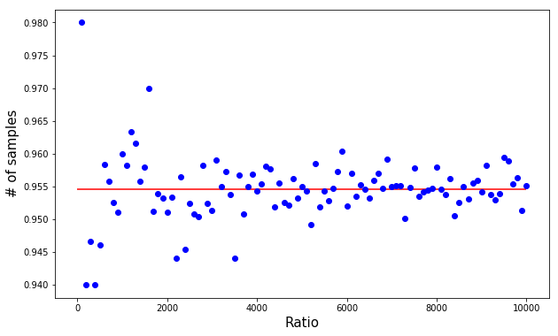

```python
n_iter = 100

def compute_ratio(N):
    mu, sigma = 0, 1
    sample = np.random.randn(N,1)
    condition = np.abs(sample - mu) <= 2*sigma
    ratio = np.mean(condition)
    return ratio

plt.figure(figsize=(10,6))
for i in range(1, n_iter+1):
    N = i*100
    ratio = compute_ratio(N)
    plt.plot(N, ratio, 'bo')
plt.hlines(0.9545, 0, 10000, 'r')
plt.xlabel('Ratio', fontsize=15)
plt.ylabel('# of samples', fontsize=15)
plt.show()
```

## Problem 3

**[Monty Hall Problem](http://en.wikipedia.org/wiki/Monty_Hall_problem) with Monte Carlo Simulations**

Suppose you’re on a game show, and you’re given the choice of three doors: Behind one door is a car; behind the others, goats. You pick a door, say No. 1, and the host, who knows what’s behind the doors, opens another door, say No. 3, which has a goat. He then says to you, “Do you want to pick door No. 2?” Is it to your advantage to switch your choice?

```python
%%html
<center><iframe width="560" height="315" src="https://www.youtube.com/embed/HH-676dOCFs?rel=0"
frameborder="0" allowfullscreen></iframe></center>
```

[video not shown]

Solve this problem with Monte Carlo simulation and print out the winning rate about 'Staying' and 'Switching'. You can utilize the below functions

```python
# without switching
N = 1000

count = 0
for i in range(N):
    car = np.random.choice([0,1,2])
    my_pick = np.random.choice([0,1,2])
    if my_pick == car : count += 1

ratio = count/N
print('{}'.format(ratio))
```

```
0.325
```

```python
# with switching
N = 1000

count = 0
for i in range(N):
    car = [np.random.choice([0,1,2])]
    my_pick = [np.random.choice([0,1,2])]

    if my_pick == car:
        host_pick = np.random.choice([i for i in [0,1,2] if i not in my_pick])
    else:
        host_pick = [i for i in [0,1,2] if i not in my_pick + car]

    my_pick = [i for i in [0,1,2] if i not in my_pick + host_pick]
    if my_pick == car : count += 1

ratio = count/N
print('{}'.format(ratio))
```

```
0.687
```

## Problem 4

Download this data [reg_pca_data](https://www.dropbox.com/sh/n56f2y2vo9t876l/AADExG_yeB-druiUAQgSXo-za?dl=1)

```python
x_reg = cPickle.load(open('./image_files/x_reg.pkl', 'rb'))
y_reg = cPickle.load(open('./image_files/y_reg.pkl', 'rb'))
```

1) Write a python code to conduct a linear regression (least square).

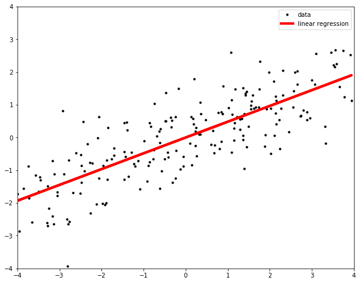

```python
x_reg = x_reg.reshape(-1, 1)
y_reg = y_reg.reshape(-1, 1)
ones_col = np.ones((x_reg.size, 1))
phi = np.hstack([x_reg, ones_col])

w = cvx.Variable(2)
objective = cvx.Minimize(cvx.sum_squares(phi * w - y_reg))
prob = cvx.Problem(objective)
prob.solve()
w = w.value

plt.figure(figsize = (10, 8))
plt.plot(x_reg, y_reg, 'k.', label = 'data')
plt.plot(x_reg, x_reg * w[0] + np.ones((200, 1)) * w[1], color = 'red', label = 'linear regression', linewidth = 4.0)
plt.xlim(-4,4)
plt.ylim(-4,4)
plt.legend()
plt.show()
```

2) Write a python code to perform PCA. Since `mean(x) = mean(y) = 0`, normalization step (mean subtraction and rescaling) can be skipped.

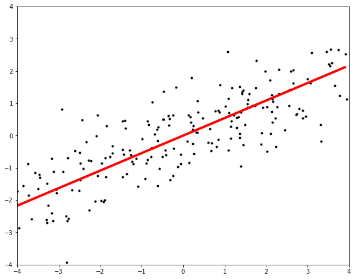

```python
num_data = x_reg.size
data = np.hstack([x_reg, y_reg])
data = np.asmatrix(data)
S = 1 / (num_data - 1) * data.T * data

D, V = np.linalg.eig(S)
idx = np.argsort(-D)
D = D[idx]; V = V[:, idx]
h = V[1, 0] / V[0, 0]
xp = np.arange(-4, 4, 0.1)
yp = h * xp;

plt.figure(figsize = (10, 8))
plt.plot(x_reg, y_reg, 'k.')
plt.plot(xp, yp, 'r', linewidth = 4.0)
plt.xlim(-4,4)
plt.ylim(-4,4)
plt.show()
```

3) Comment on why the results are different as shown in Figure 6?

[figure not shown]

Figure 6

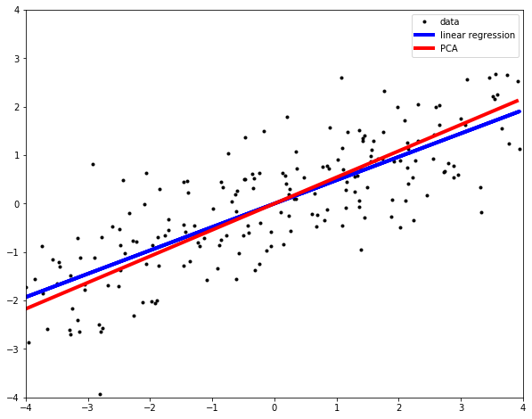

```python
fig = plt.figure(figsize=(10, 8))
plt.plot(x_reg, y_reg, 'k.', label = 'data')
plt.plot(x_reg, x_reg * w[0] + np.ones((200, 1)) * w[1], 'b', linewidth = 4.0, label = 'linear regression')
plt.plot(xp, yp, 'r', linewidth = 4.0, label = 'PCA')
plt.xlim(-4,4)
plt.ylim(-4,4)
plt.legend()
plt.show()
```

## Problem 5

We want to find a major axis in a different way from what we learned in PCA class. Load [PCA_data](https://www.dropbox.com/sh/dk7ls0emvskeq2g/AADP7BEmqSZc72g-g6NpPX9Sa?dl=1).

1) Plot the principal component (unit vector $u_1$) with the largest variance using PCA (i.e., eigen-analysis).

```python
X = cPickle.load(open('./image_files/X.pkl', 'rb'))
```

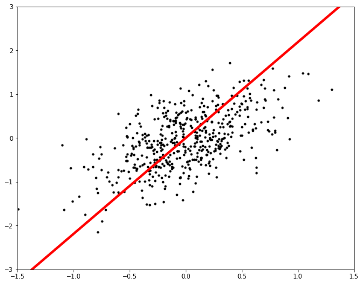

```python
X = X.reshape(500,2)

X1 = X[:,0]
Y1 = X[:,1]
X1 = np.array(X1).reshape(-1, 1); Y1 = np.array(Y1).reshape(-1, 1)

data = np.hstack([X1, Y1])
data = np.asmatrix(data)
num_data = X1.size
S = 1 / (num_data - 1) * data.T * data
D, V = np.linalg.eig(S)
idx = np.argsort(-D)
D = D[idx]; V = V[:, idx]
h = V[1, 0] / V[0, 0]

xp = np.arange(-1.5, 1.5, 0.05)
yp = h * xp;

plt.figure(figsize=(10,8))
plt.plot(X1, Y1, 'k.')
plt.plot(xp, yp, 'r', linewidth = 4.0)
plt.xlim(-1.5, 1.5)
plt.ylim(-3,3)
plt.show()
```

2) Create an arbitrary unit vector $u$. Then, multiply the sample variance matrix to $u$. After each multiplication, normalize $u$ to make it an unit vector and observe (and plot) the direction of vector $u$. Compare it with the principal vector $u_1$ computed in 1). Are they pointing at the same (or opposite) direction? If the answer is yes, explain why they are parallel. (parallel = point either at the same or opposite direction)

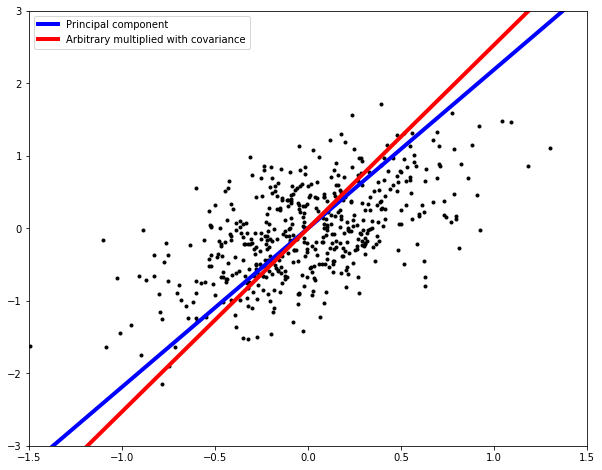

```python
u = np.random.rand(2, 1)
u = u / np.linalg.norm(u, 2)
u = np.dot(S, u)
u = u / np.linalg.norm(u, 2)

h2 = u[1] / u[0]
xp2 = np.arange(-1.5, 1.5, 0.05)
yp2 = (h2 * xp).reshape(-1, 1)

plt.figure(figsize=(10, 8))
plt.plot(X1, Y1, 'k.')
plt.plot(xp, yp, 'b', linewidth = 4.0, label = 'Principal component')
plt.plot(xp2, yp2, 'r', linewidth = 4.0, label = 'Arbitrary multiplied with covariance')
plt.xlim(-1.5, 1.5)
plt.ylim(-3,3)
plt.legend()
plt.show()
```

## Problem 6

1) Solve the problem with Fisher Discriminant Analysis and plot the projection line.

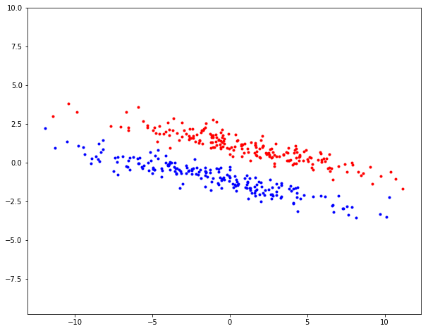

```python
n0 = 200
n1 = 200

sigma = [[19, -4],
         [-4, 1]]

x0 = np.random.multivariate_normal([1,1], sigma, n0)        # data in class 0
x1 = np.random.multivariate_normal([-1,-1], sigma, n1)      # data in class 0

plt.figure(figsize = (10, 8))
plt.plot(x0[:,0],x0[:,1],'r.')
plt.plot(x1[:,0],x1[:,1],'b.')
plt.axis('equal')
plt.show()
```

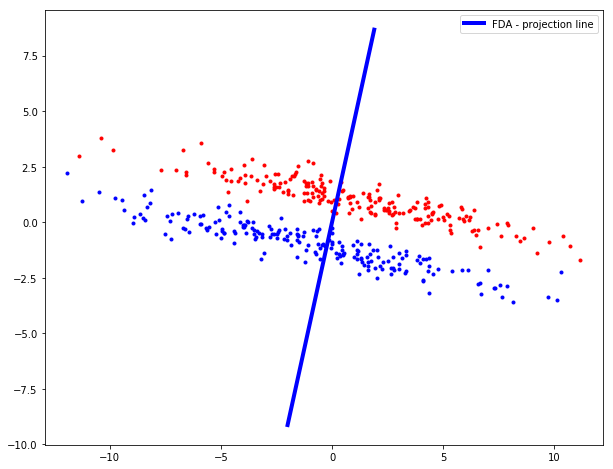

```python
x0 = np.asmatrix(x0)
x1 = np.asmatrix(x1)

mu0 = np.mean(x0, axis = 0)
mu1 = np.mean(x1, axis = 0)
S0 = 1 / (n0 - 1) * (x0 - mu0).T * (x0 - mu0)
S1 = 1 / (n1 - 1) * (x1 - mu1).T * (x1 - mu1)

w = (n0 * S0 + n1 * S1).I * (mu0 - mu1).T
h = w[1] / w[0]
xp = np.arange(-2, 2, 0.1)
yp = (h * xp).reshape(-1, 1)

plt.figure(figsize = (10, 8))
plt.plot(x0[:,0],x0[:,1],'r.')
plt.plot(x1[:,0],x1[:,1],'b.')
plt.plot(xp, yp, 'b', linewidth = 4.0, label = 'FDA - projection line')
plt.legend()
plt.axis('equal')
plt.show()
```

2) Solove the above problem with PCA and plot the projection line. In the case of PCA, you do not need to consider labels.(*i.e.* data class)

```python
X = np.vstack([x0.T, x1.T])
m = X.shape[0]

S = 1/(m-1)*X.T*X
S = np.asmatrix(S)

D, V = np.linalg.eig(S)

idx = np.argsort(-D)
D = D[idx]
V = V[:,idx]

y_pca = V[1,0]/V[0,0]*X
```

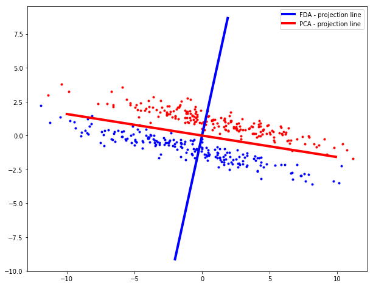

```python
data = np.vstack([x0, x1])
data = np.asmatrix(data)
num_data = data.shape[0]
S = 1 / (num_data - 1) * data.T * data

D, V = np.linalg.eig(S)
idx = np.argsort(-D)
D = D[idx]; V = V[:, idx]
h2 = V[1, 0] / V[0, 0]
xp2 = np.arange(-10, 10, 0.1)
yp2 = h2 * xp2

plt.figure(figsize = (10, 8))
plt.plot(x0[:,0],x0[:,1],'r.')
plt.plot(x1[:,0],x1[:,1],'b.')
plt.plot(xp, yp, 'b', linewidth = 4.0, label = 'FDA - projection line')
plt.plot(xp2, yp2, 'r', linewidth = 4.0, label = 'PCA - projection line')
plt.legend()
plt.axis('equal')
plt.show()
```